# ANALISIS PACKAGE R - DISTRIBUSI GAMMA BETA

KELOMPOK 7 - KOMPUTASI STATISTIKA

02 August 2025

# 1 **Distribusi Gamma**

## 1.1 **Definisi Singkat**

> *Distribusi Gamma* adalah distribusi probabilitas kontinu yang umum digunakan dalam statistik, terutama untuk memodelkan waktu sampai terjadinya suatu kejadian (misalnya waktu hidup suatu komponen) jika laju kejadiannya bersifat konstan. Distribusi Gamma *menggeneralisasi distribusi Eksponensial*, artinya jika kita menjumlahkan beberapa variabel acak eksponensial (dengan parameter yang sama), hasilnya mengikuti distribusi Gamma.

## 1.2 **Fungsi Kepadatan (PDF)**

Fungsi kepadatan probabilitas (PDF) dari distribusi Gamma adalah:

$$f(x; \alpha, \beta) = \frac{1}{\Gamma(\alpha)\beta^\alpha} x^{\alpha -
1} e^{-x/\beta}, \quad x > 0$$
**Keterangan:**

- $\Gamma(\alpha)$: fungsi gamma (generalisasi dari faktorial), $\Gamma(n) = (n - 1)!$ jika $n$ bilangan bulat.
- $\alpha$: parameter bentuk (*shape*).
- $\beta$: parameter skala (*scale*).
- $x$: variabel acak kontinu, dengan syarat $x > 0$.

## 1.3 **Fungsi Distribusi Kumulatif (CDF)**

Fungsi distribusi kumulatif (CDF) dari distribusi Gamma adalah:

$$F(x; \alpha, \beta) = \frac{1}{\Gamma(\alpha)} \int_0^{x/\beta}
t^{\alpha - 1} e^{-t} \, dt$$

**Penjelasan Tambahan:**

- $\Gamma(\alpha)$: fungsi gamma lengkap.
- $\int_0^{x/\beta} t^{\alpha - 1} e^{-t} dt$: fungsi gamma tak lengkap bawah (*lower incomplete gamma function*).
- Nilai batas atas $\frac{x}{\beta}$ muncul karena proses substitusi variabel pada skala.

## 1.4 **Eksplorasi Bentuk Distribusi Gamma**

Untuk memahami bentuk distribusi Gamma, kita dapat membandingkan grafiknya pada beberapa kombinasi nilai parameter:

**Vektor nilai x**

```r
x <- seq(0, 15, length.out = 300)
```

**Beberapa kombinasi parameter**

```r
y1 <- dgamma(x, shape = 1, rate = 1)       # alpha = 1, beta = 1
y2 <- dgamma(x, shape = 3, rate = 3)       # alpha = beta
y3 <- dgamma(x, shape = 5, rate = 1)       # alpha > beta
```

**Plot**

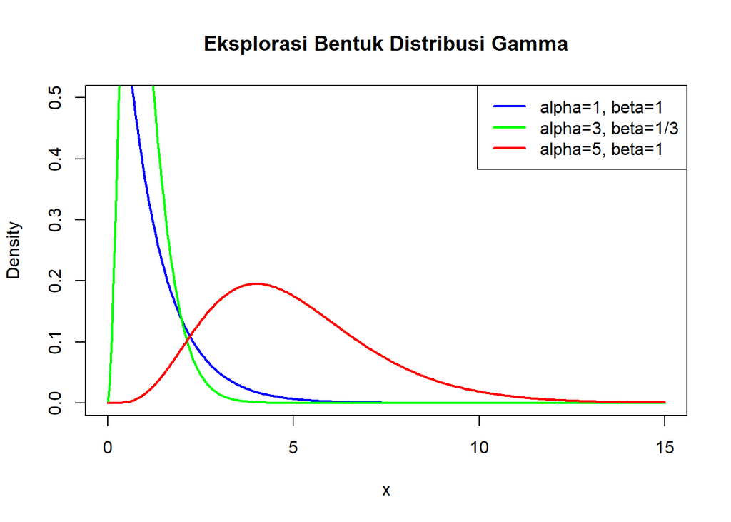

```r
plot(x, y1, type = "l", col = "blue", lwd = 2, ylim = c(0, 0.5),
     main = "Eksplorasi Bentuk Distribusi Gamma",
     xlab = "x", ylab = "Density")
lines(x, y2, col = "green", lwd = 2)
lines(x, y3, col = "red", lwd = 2)
legend("topright", legend = c("alpha=1, beta=1", "alpha=3, beta=1/3", "alpha=5, beta=1"),
       col = c("blue", "green", "red"), lwd = 2)
```

## 1.5 Studi Kasus: Analisis Volume Lalu Lintas dengan Distribusi Gamma

Pada akhir pekan, dilakukan pengamatan terhadap volume arus lalu lintas di Jalan Padang Panjang – Bukittinggi Km.5, yang merupakan jalur berbukit. Pengamatan dilakukan selama dua hari, yaitu hari **Sabtu** dan **Minggu**, masing-masing pada tiga periode waktu: pagi, siang, dan sore.

Hasil pengamatan sebagai berikut:

| Waktu | Volume Sabtu (kend/jam) | Volume Minggu (kend/jam) |
| --- | --- | --- |
| Pagi | 1435 | 2491 |
| Siang | 1939 | 1993 |
| Sore | 2333 | 2778 |

## 1.6 **Analisis di R**

```r
library(Packgamabeta)
```

### 1.6.1 LAKUKAN INPUTASI DATA VOLUME KENDARAAN PER JAM

```r
sabtu <- c(1435, 1939, 2333)
minggu <- c(2491, 1993, 2778)
```

### 1.6.2 HITUNG ESTIMASI PARAMETER GAMMA (SABTU) MENGGUNAKAN MLE UNTUK MENGHITUNG NILAI PDF

```r
params_sabtu <- gamma_mle_natural(sabtu)

cat("Estimasi Parameter Gamma - Hari Sabtu:\n")
```

```
## Estimasi Parameter Gamma - Hari Sabtu:
```

```r
cat("Shape (α):", round(params_sabtu$shape, 4), "\n")
```

```
## Shape (α): 17.8613
```

```r
cat("Rate  (λ):", round(params_sabtu$rate, 4), "\n")
```

```
## Rate  (λ): 0.0094
```

```r
cat("Nilai Likelihood:", round(params_sabtu$likelihood, 4), "\n\n")
```

```
## Nilai Likelihood: 0
```

### 1.6.3 ESTIMASI PARAMETER GAMMA (MINGGU) MENGGUNAKAN MLE

```r
params_minggu <- gamma_mle_natural(minggu)

cat("Estimasi Parameter Gamma - Hari Minggu:\n")
```

```
## Estimasi Parameter Gamma - Hari Minggu:
```

```r
cat("Shape (α):", round(params_minggu$shape, 4), "\n")
```

```
## Shape (α): 37.1412
```

```r
cat("Rate  (λ):", round(params_minggu$rate, 4), "\n")
```

```
## Rate  (λ): 0.0153
```

```r
cat("Nilai Likelihood:", round(params_minggu$likelihood, 4), "\n\n")
```

```
## Nilai Likelihood: 0
```

### 1.6.4 PLOT PDF DISTRIBUSI GAMMA UNTUK HARI SABTU

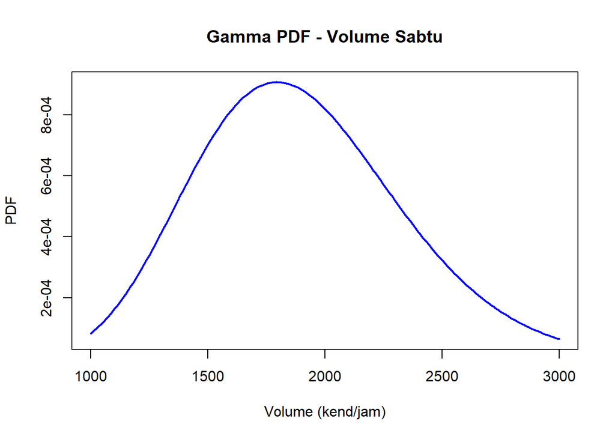

```r
x_sabtu <- seq(1000, 3000, length.out = 200)
pdf_sabtu <- dgamma_natural(x_sabtu, shape = params_sabtu$shape, rate = params_sabtu$rate)

plot(x_sabtu, pdf_sabtu, type = "l", col = "blue", lwd = 2,
     main = "Gamma PDF - Volume Sabtu",
     xlab = "Volume (kend/jam)", ylab = "PDF")
```

### PLOT PDF DISTRIBUSI GAMMA UNTUK HARI MINGGU

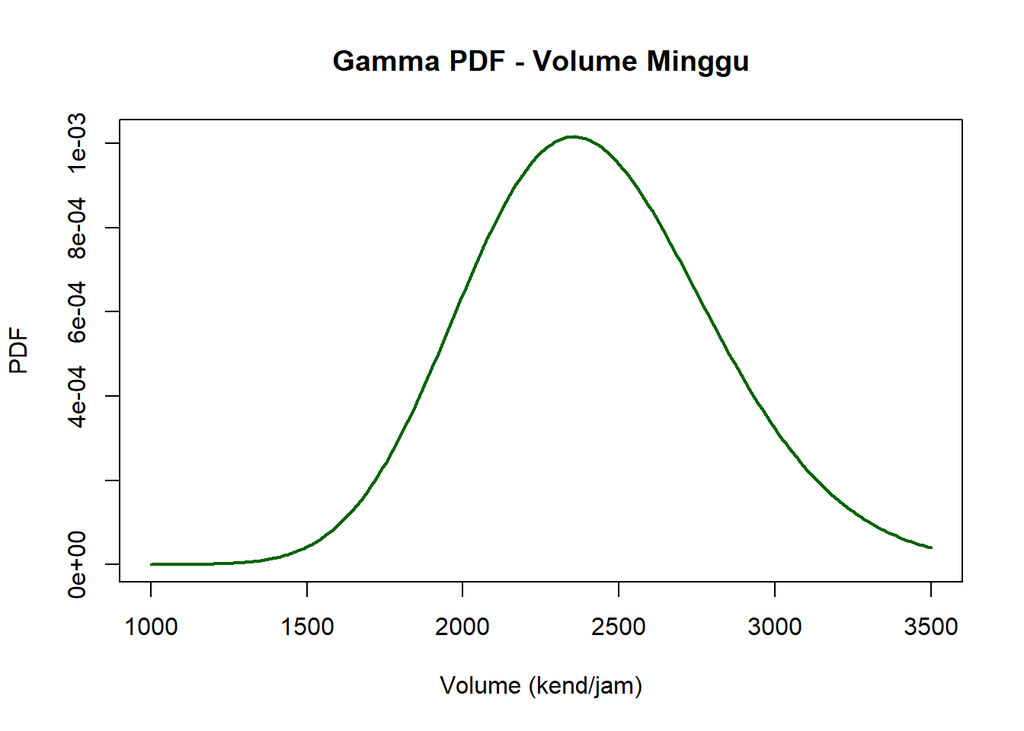

```r
x_minggu <- seq(1000, 3500, length.out = 200)
pdf_minggu <- dgamma_natural(x_minggu, shape = params_minggu$shape, rate = params_minggu$rate)

plot(x_minggu, pdf_minggu, type = "l", col = "darkgreen", lwd = 2,
     main = "Gamma PDF - Volume Minggu",
     xlab = "Volume (kend/jam)", ylab = "PDF")
```

### SIMULASI DATA DENGAN gamma_montecarlo DAN HISTOGRAM

[figure not shown]

```r
set.seed(42)
simul_sabtu <- gamma_montecarlo(100, params_sabtu$shape, params_sabtu$rate)

hist(simul_sabtu, breaks = 15, col = "skyblue",
     main = "Simulasi Monte Carlo - Gamma Sabtu",
     xlab = "Volume Kendaraan per Jam")
```

# 2 **Distribusi Beta**

## 2.1 **Definisi Singkat**

> Distribusi Beta adalah salah satu distribusi dasar dalam statistik yang didefinisikan pada interval $[0, 1]$. Distribusi ini memiliki banyak aplikasi dalam statistik klasik maupun pendekatan Bayesian.Distribusi Beta melibatkan pengertian **fungsi beta**, yang merupakan komponen penting dalam mendefinisikan bentuk fungsi kepadatan probabilitas (PDF)-nya.

## 2.2 **Integral Beta**

Sebelum membahas lebih jauh tentang distribusi Beta, terlebih dahulu kita mengenal **fungsi beta (integral beta)** beserta sifat-sifat dasarnya.

Integral beta didefinisikan sebagai:

$$B(\alpha, \beta) = \int_0^1 t^{\alpha - 1} (1 - t)^{\beta - 1} \, dt$$

Fungsi beta juga dapat dituliskan menggunakan **fungsi gamma**:

$$B(\alpha, \beta) = \frac{\Gamma(\alpha)\Gamma(\beta)}{\Gamma(\alpha +
\beta)}$$
Dengan:

$$\Gamma(n) = (n - 1)! \quad \text{untuk bilangan bulat positif } n$$

## 2.3 **Fungsi Kepadatan (PDF) Distribusi Beta**

Distribusi Beta didefinisikan untuk $x \in [0, 1]$, dan parameter positif $\alpha > 0$ dan $\beta > 0$.

Fungsi PDF distribusi Beta:

$$f(x; \alpha, \beta) = \frac{1}{B(\alpha, \beta)} \cdot x^{\alpha - 1}
\cdot (1 - x)^{\beta - 1}, \quad \text{untuk } 0 < x < 1$$

dengan:

- $\alpha$ dan $\beta$ adalah parameter bentuk (*shape parameters*)
- $B(\alpha, \beta)$ adalah fungsi beta sebagai konstanta normalisasi:

$$B(\alpha, \beta) = \int_0^1 t^{\alpha - 1}(1 - t)^{\beta - 1} dt =
\frac{\Gamma(\alpha)\Gamma(\beta)}{\Gamma(\alpha + \beta)}$$

- $\Gamma(\cdot)$ adalah fungsi gamma, dengan:

$$\Gamma(n) = (n - 1)! \quad \text{jika } n \text{ bilangan bulat positif}$$

## 2.4 **Fungsi Distribusi Kumulatif (CDF) Distribusi Beta**

$$F(x; \alpha, \beta) = \int_0^x f(t; \alpha, \beta) dt =
\frac{1}{B(\alpha, \beta)} \int_0^x t^{\alpha - 1}(1 - t)^{\beta - 1} dt$$

- $I_x(\alpha, \beta)$ disebut fungsi beta tidak lengkap teratur (*regularized incomplete beta function*):

$$I_x(\alpha, \beta) = \frac{1}{B(\alpha, \beta)} \int_0^x t^{\alpha -
1}(1 - t)^{\beta - 1} dt$$

## 2.5 **Eksplorasi Bentuk Distribusi Beta**

Distribusi Beta dapat mengambil berbagai bentuk tergantung pada nilai parameter **α (alpha)** dan **β (beta)**. Distribusi ini didefinisikan pada interval $0 < x < 1$, dan sangat fleksibel untuk memodelkan probabilitas, proporsi, atau ketidakpastian.

**Visualisasi Bentuk Distribusi Beta**

Contoh Parameter yang Digunakan:

- $\alpha = \beta = 2$: Simetris dan berbentuk lonceng
- $\alpha = \beta = 0.5$: U-shape (cekung)
- $\alpha = 5, \beta = 1$: Condong ke kiri
- $\alpha = 1, \beta = 5$: Condong ke kanan
- $\alpha = 2, \beta = 5$: Modarat condong ke kanan
- $\alpha = 5, \beta = 2$: Modarat condong ke kiri

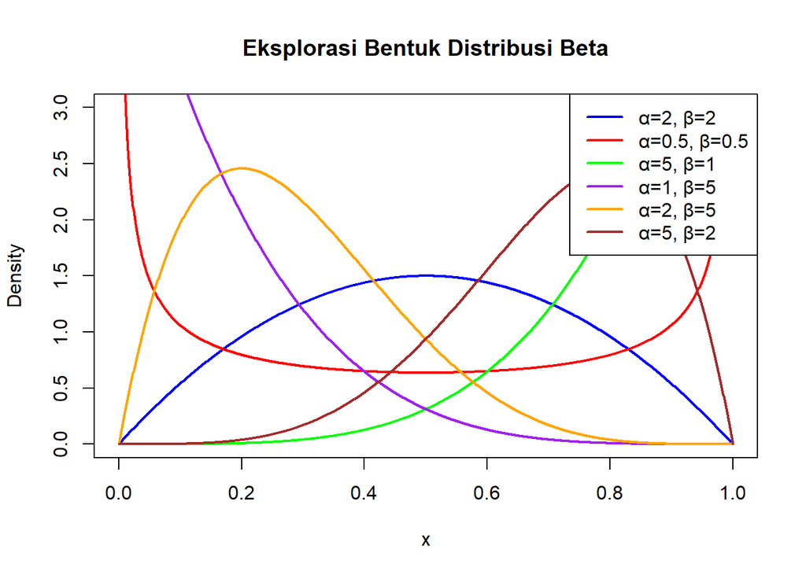

```r
x <- seq(0, 1, length.out = 1000)

plot(x, dbeta(x, 2, 2), type = "l", col = "blue", lwd = 2,
     ylim = c(0, 3), ylab = "Density", xlab = "x",
     main = "Eksplorasi Bentuk Distribusi Beta")

lines(x, dbeta(x, 0.5, 0.5), col = "red", lwd = 2)     # U-shape
lines(x, dbeta(x, 5, 1), col = "green", lwd = 2)       # condong kiri
lines(x, dbeta(x, 1, 5), col = "purple", lwd = 2)      # condong kanan
lines(x, dbeta(x, 2, 5), col = "orange", lwd = 2)      # modarat condong kanan
lines(x, dbeta(x, 5, 2), col = "brown", lwd = 2)       # modarat condong kiri

legend("topright",
       legend = c("α=2, β=2", "α=0.5, β=0.5", "α=5, β=1", "α=1, β=5", "α=2, β=5", "α=5, β=2"),
       col = c("blue", "red", "green", "purple", "orange", "brown"),
       lwd = 2)
```

## 2.6 Studi Kasus Distribusi Beta: Waktu Kerusakan Piston Mesin

```r
library(Packgamabeta)
```

### 2.6.1 DATA FAILURE TIME (TAHUN)

```r
# Data awal
data_awal <- c(0.41, 0.58, 0.75, 0.85, 1.00, 1.08, 1.17, 1.25)

# Normalisasi ke [0,1], dengan sedikit perbaikan agar tidak mencapai nilai 0 atau 1
x_min <- min(data_awal)
x_max <- max(data_awal)
epsilon <- 1e-6  # Menambahkan epsilon agar tidak mencapai nilai 0 dan 1

# Hindari nilai 0 dan 1 dalam data normalisasi
data_beta <- (data_awal - x_min + epsilon) / (x_max - x_min + 2 * epsilon)  # Tambahkan epsilon ekstra di pembagi

# Pastikan data berada dalam rentang (0,1)
print(range(data_beta))  # Verifikasi rentang data
```

```
## [1] 1.190473e-06 9.999988e-01
```

### 2.6.2 ESTIMASI PARAMETER BETA DENGAN MLE

```r
params_beta <- beta_mle(data_beta)

cat("Estimasi Parameter Beta:\n")
```

```
## Estimasi Parameter Beta:
```

```r
cat("Alpha (α):", round(params_beta$alpha, 4), "\n")
```

```
## Alpha (α): 0.2478
```

```r
cat("Beta  (β):", round(params_beta$beta, 4), "\n")
```

```
## Beta  (β): 0.229
```

### 2.6.3 PROBABILITAS WAKTU KERUSAKAN ≤ 0.3 (CDF)

```r
cdf_03 <- pbeta_scratch(0.3, params_beta$alpha, params_beta$beta)
cat("Probabilitas kerusakan terlalu cepat (≤ 0.3):", round(cdf_03, 4), "\n")
```

```
## Probabilitas kerusakan terlalu cepat (≤ 0.3): 0.403
```

### 2.6.4 GRAFIK PDF DISTRIBUSI BETA

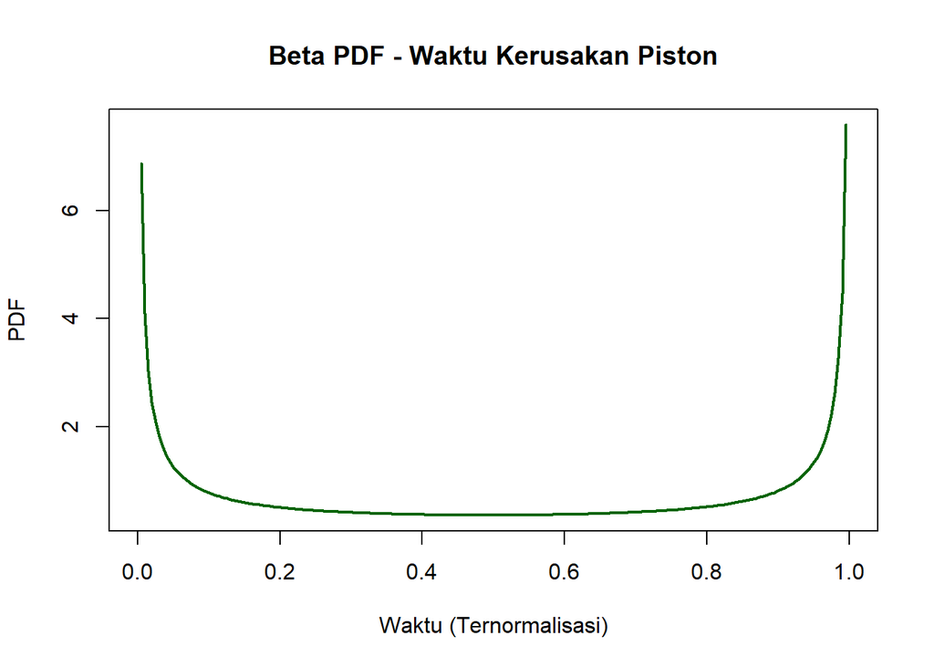

```r
x_vals <- seq(0, 1, length.out = 200)
pdf_vals <- dbeta_scratch(x_vals, params_beta$alpha, params_beta$beta)

plot(x_vals, pdf_vals, type = "l", col = "darkgreen", lwd = 2,
     main = "Beta PDF - Waktu Kerusakan Piston",
     xlab = "Waktu (Ternormalisasi)", ylab = "PDF")
```

### 2.6.5 PDF DI TITIK-TITIK STRATEGIS: 0.2, 0.5, 0.8

```r
titik <- c(0.2, 0.5, 0.8)
pdf_titik <- dbeta_scratch(titik, params_beta$alpha, params_beta$beta)
names(pdf_titik) <- titik
pdf_titik
```

```
##       0.2       0.5       0.8
## 0.5085703 0.3667500 0.5219353
```

### 2.6.6 SIMULASI MONTE CARLO DAN HISTOGRAM

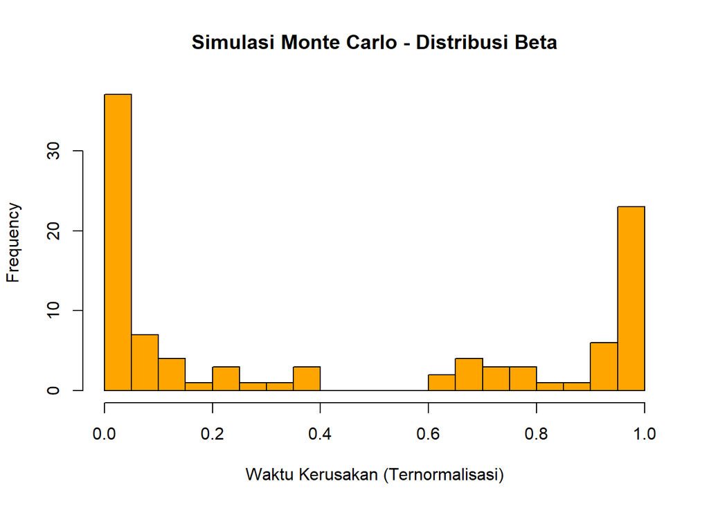

```r
set.seed(123)
simul_beta <- beta_montecarlo(100, params_beta$alpha, params_beta$beta)

hist(simul_beta, breaks = 15, col = "orange",
     main = "Simulasi Monte Carlo - Distribusi Beta",
     xlab = "Waktu Kerusakan (Ternormalisasi)")
```